# Combination Formula

## Combination Formula

Also known as selection formula.

That is if a set of objects is given to us, how many ways can we select a sibset of those objects

$$n_{C_r} = { n!\over {r!(n-r)!}}$$

The above formula is used for finding the number of ways to select the subset

E.g. we have the following 7 objects:

$$\begin{matrix}A & B & C & D & E & F & G\end{matrix}$$

How many ways can we select any three (3) objects:

$$\begin{matrix}A & B & C \end{matrix}$$$$\begin{matrix}A & B & D \end{matrix}$$$$\begin{matrix}A & C & B\end{matrix}$$

But last one is incorrect, as its a permutation, i.e. interchanging of position is not allowed.

There is another formula called n p (permutation) r, but this is n c (combination) r, i.e. selection/combination formula

Lets create a function for ncr:

So if n = 5, then r can take up values from 0 - 5, so it can be

$$5_{C_r} = { \begin{matrix}5_{C_0} & 5_{C_1} & 5_{C_2} & 5_{C_3} & 5_{C_4} & 5_{C_5}\end{matrix}}$$

NOTE: first number starts at 0, and last number can be up to n, but not more.

So first have a look at simple (formula) function for this

```python
#include <iostream>
#include <climits>
#include <math.h>
using namespace std;
```

## Using simplex function as per the formula

$$ { n!\over {r!(n-r)!}}$$

Some basic logic of the function:

Take three variable, t1, t2, t3, and set it equal to the three factorial expressions:

t1 = fact(n);

t2 = fact(r);

t3= fact(n-r);

and return the formula (t1/(t2*t3);

How much time? Fact functions we know take order of n times (x3)

others ate simple statements, constant time..

So 3n is order of n

So time taken is $$\text O(n) $$

Next lets construct a recursive function.

```python
int C_simple(int n, int r);
int fact(int n);
```

```python
int fact(int n){
    if (n ==0)
       return 1;
    else
       return fact(n-1)*n;

}
```

```python
int ncr_simple(int n,int r){
    //int t1, t2, t3;

    //t1 = fact(n);
    //t2 = fact(r);
    //t3 = fact(n-r);

    //return t1/(t2*t3);1

    int num, den;
    num = fact(n);
    den = fact(r)* fact(n-r);
    return num/den;


}
```

```python
int x20=7,y20=3;
int z20=0;
z20 =ncr_simple(x20,y20);
```

```python
cout<<z20<<endl;
```

```
35
```

## Recursive Function

Firstly we need to have a look at Pascals triangle:

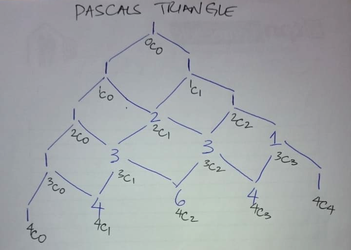

Pascals triangle show that the value for ncr can be obtained by performing ADDITION recursively

How is this possible, lets construct the triangle

$$\begin{matrix} &&&&&1\\ &&&&1&&1\\ &&&1&&2&&1\\ &&1&&3&&3&&1\\ &1&&4&&6&&4&&1 \end{matrix}$$

And how can we relate this to ncr:

$$\begin{matrix} &&&&&{1}_{0_{C_0}}\\ &&&&{1}_{1_{C_0}}&&{1}_{1_{C_1}}\\ &&&{1}_{2_{C_0}}&&{2}_{2_{C_1}}&&{1}_{2_{C_2}}\\ &&{1}_{3_{C_0}}&&{3}_{3_{C_1}}&&{3}_{3_{C_2}}&&{1}_{3_{C_3}}\\ &{1}_{4_{C_0}}&&{4}_{4_{C_1}}&&{6}_{4_{C_2}}&&{4}_{4_{C_3}}&&{1}_{4_{C_4}} \end{matrix}$$

So from pascals triangle we can find the values for ncr

So now from pascals triangle can we get a function for this?

E.g. $4_{C_2}$ can be obtained by adding $3_{C_1}$ and $3_{C_2}$

$$4_{C_2} = 3_{C_1}+ 3_{C_2}$$

And how is $3_{C_1}$ obtained by adding,

$$3_{C_1} = 2_{C_0}+ 2_{C_1}$$

And how is $3_{C_2}$ obtained by adding,

$$3_{C_2} = 2_{C_1}+ 2_{C_2}$$

..etc etc ...etc etc...etc ....its RECURSIVE

If $4_{C_2}$ is ncr, and $n=4$, $r=2$

So $3_{C_1}$ = ${n-1}_{C_{r-1}} $

and $3_{C_2}$ = ${n-1}_{C_r} $

Base on that we can define a recursive function...

```python
int comRec(int n, int r);
```

```python
int comRec(int n, int r){
    if(r==0 || n==r)
        return 1;
    return comRec(n-1, r-1) + comRec(n-1,r);

}
```

```python
int x=7,y=3;
int z=0;
z =comRec(x,y);
```

```python
cout<<z<<endl;
```

```
35
```